BIF-7900 · Bioinformatique I · Visualisation avec R

# Activité : auditer un script ggplot2 généré par IA

**Important**

**Corrigé.** Réservé à la correction en classe : à déposer après la séance.

**Activité formative, non notée**

# Contexte

L’équipe pédagogique veut comparer les deux cohortes d’étudiants du cours (`Cycle 1` et `Cycle 2 et 3`). Elle dispose du fichier `grades.tsv` du module 6 : une ligne par étudiant, `ID_etu`, les notes sur 100 de six évaluations dans l’ordre du trimestre (`D1`, `D2`, `E1`, `D3`, `D4`, `E2`), `Annee` et `Cohorte`.

Elle a demandé à un assistant d’IA :

> *« À partir de grades.tsv, compare les deux cohortes : (1) la distribution des notes de chaque évaluation, dans l’ordre du trimestre (D1, D2, E1, D3, D4, E2) ; (2) un barplot de la note moyenne de chaque cohorte. Les notes sont sur 100. »*

Voici le script obtenu. Il a été écrit pour cet exercice, dans le style d’un assistant d’IA. **Il s’exécute sans aucune erreur.**

```r
library(tidyverse)
# Script vérifié : s'exécute sans erreur.
notes <- read_tsv("/home/public/tidyverse/grades.tsv")

notes_long <- notes |>
  pivot_longer(D1:E2, names_to = "Type", values_to = "Note")

# 1. Distribution des notes par évaluation et par cohorte
ggplot(notes_long, aes(x = Type, y = Note, fill = Cohorte)) +
  geom_boxplot() +
  scale_y_continuous(limits = c(50, 100)) +   # les notes sont sur 100
  theme_bw()

# 2. Note moyenne par cohorte
ggplot(notes_long, aes(x = Cohorte, y = Note, fill = "steelblue")) +
  geom_col() +
  labs(y = "Note moyenne")
```

Le script contient **au moins 3 erreurs**. Aucune ne produit d’erreur : les graphiques ont l’air normaux, mais ils sont faux ou ne répondent pas à la demande. Attention, certaines lignes sont **correctes** : ne corrigez que ce qui doit l’être.

# Les graphiques du script d’origine

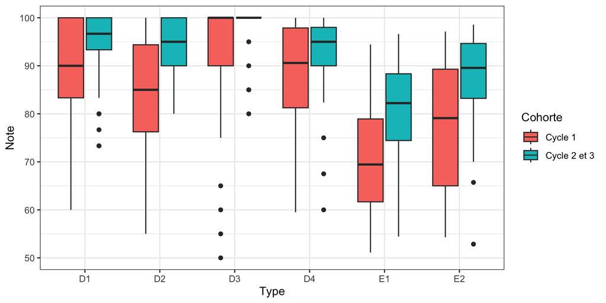

```r
ggplot(notes_long, aes(x = Type, y = Note, fill = Cohorte)) +
  geom_boxplot() +
  scale_y_continuous(limits = c(50, 100)) +
  theme_bw()
```

```
#> Warning: Removed 1 row containing missing values or values outside the scale range
#> (`geom_col()`).
```

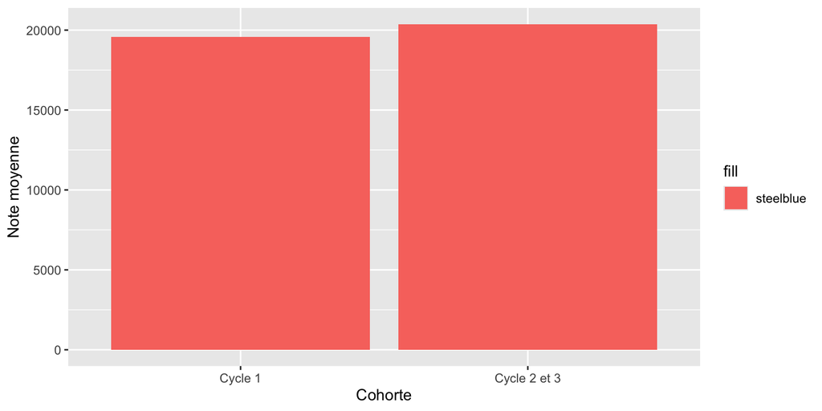

```r
ggplot(notes_long, aes(x = Cohorte, y = Note, fill = "steelblue")) +
  geom_col() +
  labs(y = "Note moyenne")
```

# Erreur 1 : `limits` retire des notes

```r
notes_long |> summarise(sous_50 = sum(Note < 50, na.rm = TRUE), manquantes = sum(is.na(Note)))
```

```
#> # A tibble: 1 × 2
#>   sous_50 manquantes
#>     <int>      <int>
#> 1      21          1
```

```r
notes_long |>
  summarise(mediane = median(Note, na.rm = TRUE),
            mediane_sup50 = median(Note[Note >= 50], na.rm = TRUE), .by = Type)
```

```
#> # A tibble: 6 × 3
#>   Type  mediane mediane_sup50
#>   <chr>   <dbl>         <dbl>
#> 1 D1       93.3          93.3
#> 2 D2       90            90
#> 3 E1       75.6          75.6
#> 4 D3      100           100
#> 5 D4       94.1          95
#> 6 E2       82.9          85.4
```

Le commentaire `# les notes sont sur 100` est juste… et hors sujet : il justifie la borne haute, mais la borne **basse** à 50 n’a aucune raison d’être. Si on veut fixer l’axe de 0 à 100, `limits = c(0, 100)` ne retire rien ; pour zoomer, `coord_cartesian(ylim = )`.

# Erreur 2 : les évaluations ne sont pas dans l’ordre du trimestre

`Type` est du texte : `ggplot2` le trie par ordre **alphabétique**, D1, D2, D3, D4, E1, E2. La demande précisait l’ordre du trimestre (D1, D2, **E1**, D3, D4, E2). Les deux examens se retrouvent côte à côte à la fin. On fixe l’ordre avec un facteur :

```r
mutate(Type = fct_inorder(Type))   # ou factor(Type, levels = c("D1", "D2", "E1", "D3", "D4", "E2"))
```

# Erreur 3 : le barplot montre des sommes, pas des moyennes

```r
notes_long |>
  summarise(somme = sum(Note, na.rm = TRUE), moyenne = mean(Note, na.rm = TRUE), n = n(), .by = Cohorte)
```

```
#> # A tibble: 2 × 4
#>   Cohorte       somme moyenne     n
#>   <chr>         <dbl>   <dbl> <int>
#> 1 Cycle 1      19570.    79.9   246
#> 2 Cycle 2 et 3 20376.    89.4   228
```

Chaque cohorte compte plus de 200 lignes dans `notes_long`. `geom_col()` **empile** toutes les lignes qui ont le même `x` : chaque barre est la **somme** des notes (~20 000), pas leur moyenne, malgré le titre de l’axe. Pire, la somme dépend de l’**effectif** : l’écart entre cohortes paraît faible (4 %), alors que la différence de moyennes est de presque 10 points. Il faut calculer la moyenne d’abord, avec `summarise()`, puis `geom_col()` ; ou utiliser `stat_summary(fun = mean, geom = "col")`.

# Erreur 4 : une couleur fixe placée dans `aes()`

Dans `aes()`, `"steelblue"` n’est pas une couleur mais **une donnée** (une colonne constante) : les barres prennent la première couleur de la palette (rouge saumon), et une légende inutile annonce « steelblue ». Une couleur fixe se met **hors** de `aes()` : `geom_col(fill = "steelblue")`.

# Ce qui était correct

- `pivot_longer(D1:E2, names_to = "Type", values_to = "Note")` : le passage au format long est juste et nécessaire.
- `aes(x = Type, y = Note, fill = Cohorte)` + `geom_boxplot()` : le bon graphique pour comparer des distributions.
- `theme_bw()` : un choix d’apparence, sans effet sur les données.

# Le commentaire « Script vérifié »

« S’exécute sans erreur » est vrai, et ne prouve rien : aucune des quatre erreurs n’en produit. Deux se voyaient pourtant en **lisant le graphique** (un axe en milliers pour des notes sur 100, une légende « steelblue »), une seulement en **lisant le warning** (les notes retirées), et une en **relisant la demande** (l’ordre). Un assistant d’IA ne regarde pas le graphique qu’il produit : c’est à la personne qui le présente de le lire.

# Script corrigé

```
#> Warning: Removed 1 row containing non-finite outside the scale range
#> (`stat_boxplot()`).
```

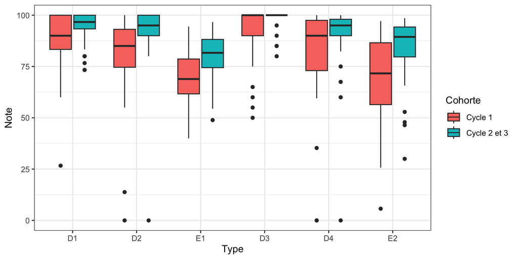

```r
library(tidyverse)

notes_long <- notes |>
  pivot_longer(D1:E2, names_to = "Type", values_to = "Note") |>
  # Correction 2 : l'ordre du trimestre (sinon alphabétique : D1, D2, D3, D4, E1, E2)
  mutate(Type = fct_inorder(Type))

# 1. Distribution des notes par évaluation et par cohorte
ggplot(notes_long, aes(x = Type, y = Note, fill = Cohorte)) +
  geom_boxplot() +
  # Correction 1 : limits retirait les notes < 50 avant le calcul ; on fixe l'axe sans rien retirer
  coord_cartesian(ylim = c(0, 100)) +
  theme_bw()
```

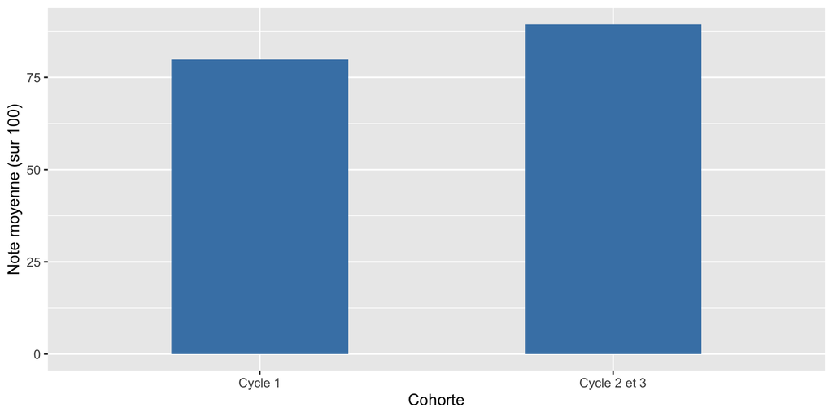

```r
# 2. Note moyenne par cohorte
moyennes <- notes_long |>
  # Correction 3 : calculer la moyenne d'abord (geom_col() additionnait les ~240 notes de chaque cohorte)
  summarise(moyenne = mean(Note, na.rm = TRUE), .by = Cohorte)

ggplot(moyennes, aes(x = Cohorte, y = moyenne)) +
  # Correction 4 : couleur fixe hors de aes() (dans aes(), "steelblue" était une donnée)
  geom_col(fill = "steelblue", width = 0.5) +
  labs(y = "Note moyenne (sur 100)")
```

# Mieux qu’un barplot

Le barplot de deux moyennes cache tout ce qui intéresse l’équipe : la dispersion, les échecs, les effectifs. Les points de chaque étudiant, avec la moyenne, en disent beaucoup plus :

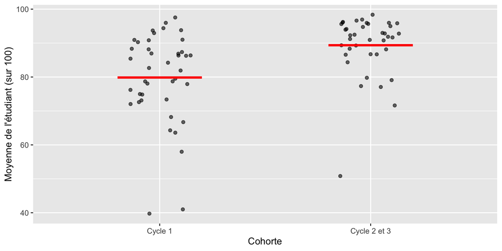

```r
moyennes_etu <- notes_long |>
  summarise(moyenne = mean(Note, na.rm = TRUE), .by = c(ID_etu, Cohorte))

ggplot(moyennes_etu, aes(x = Cohorte, y = moyenne)) +
  geom_jitter(width = 0.15, alpha = 0.6) +
  stat_summary(fun = mean, geom = "crossbar", width = 0.4, color = "red") +
  labs(y = "Moyenne de l'étudiant (sur 100)")
```